# 當愛情來敲門—-成為「愛情公寓」的人氣住戶

第11組

# **Part 1.研究動機**

隨著網路科技的發達，人際交往的方式不再侷限，各種交友網站隨之興起，而在交友網站中，什麼樣的的特質會吸引異性的目光呢？我們決定對全台最大的交友網站<愛情公寓>做分析，找出成為人氣住戶所需要的條件。

# **Part 2.小組分工**

陳靖雯:part3 (1)(2)(3)(5)

徐若華:part3 (4)

唐悅慈:口頭報告、PPT

謝欣芳:書面報告

# **Part 3.研究方法**

## **(1)資料收集**

### *個人網頁抓取*

爬蟲內容:抓取全台最大交友網站“愛情公寓”(http://www.i-part.com.tw/search/query_online.php) 上三千多名住戶的資訊如暱稱、性別、身高、體重、學歷、職業、感情狀態、居住地區、擇偶條件和人氣指數等。有來自不同領域，不同地區(包含部分港澳與歐美)等等形形色色的男女做為分析樣本。

完整程式碼:(https://github.com/Raymonna/r_FinalProject/blob/master/r_crawl.Rmd)

使用套件:httr、rvest、xml2

## **(2)資料整理**

### *(i)資料清理*

利用regular expression將雜訊去除，餘下需要的部分整理成dataframe的形式，匯出成csv檔。

完整程式碼:(https://github.com/Raymonna/r_FinalProject/blob/master/r_crawl.Rmd)

使用套件:dplyr、plotly、ggplot2

### *(ii)資料前處理*

完整程式碼:(https://github.com/Raymonna/r_FinalProject/blob/master/rProjectRegression.Rmd)

使用套件:dplyr， plotly ，ggplot2

(i)將屬性資料數值化(包含性別、單身與否、抽菸與否、酗酒與否)。

(ii)將“工作”一變數做進一步的分析，以男女分別進行圖像化分析，根據每一個工作類別取平均人氣指數，藉此當作工作受歡迎程度的指標，區分為受歡迎的工作。

[interactive chart not shown]

(iii)將“居住城市”一變數進行整理，清理雜訊並區分為台灣各縣市以及國外。

[interactive chart not shown]

## **(3)資料分析**

利用回歸分析各項條件與住戶受歡迎程度的關聯性，找出關聯性較大的性質進行下一步的分析，將“總體”、“男性”、“女性”，分別做三次回歸加以分析，而身高體重的部分，則以quadratic regression 來進行進一步分析。

使用套件: dplyr、quantreg、plm

### *(i)總體分析*:

身高=>身高愈高愈有一定優勢，但此優勢增加幅度卻為遞減，可見身高高的人還是相對比較受歡迎，但是也不能高過頭了，可能會讓人覺得有壓迫感，反而不會成為加分的點。

體重=>體重則是越輕越好，可以推測現代人追求骨感的熱潮依舊不減。 擇偶條件有寫與否=>這邊想要表達的是:並不是說若有寫擇偶條件，你的人氣就會上升。不如說較有可能的因果關係為:一個人氣高的人，可能交友選擇的條件比較多、標準比較高(比較傲嬌XD)，所以會寫上交往對象的條件。

職業=>在職業分析的部份我們發現了一個有趣的現象，對於行銷業，大家似乎會有比較好的觀感。我們猜測可能是因為行銷業的人通常比較會打扮，或相比其他職業給人較為圓融、善於交際交往的印象，所以會有比較高的人氣。

```
##
## Call:
## lm(formula = iview ~ gender + iheight + iweight + single + sig_job +
##     nosmoke + expertdrunk + saiddrink + nodrink + istudy_level +
##     ha_re, data = df)
##
## Residuals:
##    Min     1Q Median     3Q    Max
## -31961  -7483  -3112   1268 696687
##
## Coefficients: (2 not defined because of singularities)
##               Estimate Std. Error t value Pr(>|t|)
## (Intercept)  -13880.65   15780.92  -0.880  0.37922
## gender        22054.99    1954.13  11.286  < 2e-16 ***
## iheight          54.35      90.38   0.601  0.54766
## iweight         -77.36      45.87  -1.686  0.09194 .
## single         2044.75    1825.58   1.120  0.26286
## sig_job        3919.21    2401.46   1.632  0.10288
## nosmoke       -1475.93    1786.61  -0.826  0.40887
## expertdrunk         NA         NA      NA       NA
## saiddrink           NA         NA      NA       NA
## nodrink        -313.89    2643.01  -0.119  0.90548
## istudy_level   1042.52    1063.15   0.981  0.32694
## ha_re         10056.67    3239.95   3.104  0.00194 **
## ---
## Signif. codes:  0 '***' 0.001 '**' 0.01 '*' 0.05 '.' 0.1 ' ' 1
##
## Residual standard error: 29530 on 1574 degrees of freedom
##   (1480 observations deleted due to missingness)
## Multiple R-squared:  0.1125, Adjusted R-squared:  0.1074
## F-statistic: 22.17 on 9 and 1574 DF,  p-value: < 2.2e-16
```

### *(ii)女性分析*

體重身高=>相對於男性，較有顯著的影響，而其中的效果特性，近似於總體分析中身高體重對於人氣指數的影響。

學歷=>相對於男性，女性學歷似乎對人氣沒有實質幫助，而且較具影響力的碩士學歷呈現現的是負向效果，可推測有可能女子無才便是德此一觀念仍留存在現代人的潛意識中。

單身與否=>若是單身，對人氣指數有加分效果。

職業=>和前面相同，行銷業具顯著加分效果，而若選填為學生，對於人氣指數呈現相對負向關係。

居住地=>若居住地為新竹縣、台東縣、彰化縣、嘉義縣，有顯著正向效果，其中有可能的原因為大家對這些地區的女生普遍有好感，或是在比例上，這些地區的女生比較漂亮?!(有可能樣本比較少的緣故)

```
##
## Call:
## lm(formula = iview ~ polym(iheight, degree = 2, raw = TRUE) +
##     polym(iweight, degree = 2, raw = TRUE) + single + sig_job +
##     factor(ijob) + factor(istudy) + factor(icity) + nosmoke +
##     expertdrunk + saiddrink + nodrink + istudy_level + ha_re,
##     data = df_girl)
##
## Residuals:
##     Min      1Q  Median      3Q     Max
## -315238  -18460   -6930    7543  315238
##
## Coefficients: (4 not defined because of singularities)
##                                           Estimate Std. Error t value
## (Intercept)                             -1.631e+05  1.604e+05  -1.017
## polym(iheight, degree = 2, raw = TRUE)1  2.736e+03  2.020e+03   1.355
## polym(iheight, degree = 2, raw = TRUE)2 -8.143e+00  5.953e+00  -1.368
## polym(iweight, degree = 2, raw = TRUE)1 -8.678e+02  4.761e+02  -1.823
## polym(iweight, degree = 2, raw = TRUE)2  4.476e+00  2.766e+00   1.618
## single                                   5.376e+03  3.985e+03   1.349
## sig_job                                 -3.595e+04  4.233e+04  -0.849
## factor(ijob)未知                        -7.029e+03  3.497e+04  -0.201
## factor(ijob)交通/運輸                    4.735e+02  3.572e+04   0.013
## factor(ijob)行銷                         3.812e+05  3.919e+04   9.727
## factor(ijob)其他                        -1.604e+04  3.415e+04  -0.470
## factor(ijob)房地產                       7.769e+03  3.977e+04   0.195
## factor(ijob)服務                        -2.425e+04  3.415e+04  -0.710
## factor(ijob)金融保險                     4.696e+02  2.779e+04   0.017
## factor(ijob)建築營造                    -3.837e+04  4.148e+04  -0.925
## factor(ijob)待業中                      -3.313e+04  3.653e+04  -0.907
## factor(ijob)政府機關                    -1.940e+04  3.619e+04  -0.536
## factor(ijob)流通/零售                   -9.532e+03  3.557e+04  -0.268
## factor(ijob)軍警                         2.014e+03  3.914e+04   0.051
## factor(ijob)家管                        -4.106e+03  3.821e+04  -0.107
## factor(ijob)旅遊                        -4.127e+03  4.550e+04  -0.091
## factor(ijob)教育研究                    -2.265e+04  3.494e+04  -0.648
## factor(ijob)經商                                NA         NA      NA
## factor(ijob)資訊                        -2.154e+04  3.646e+04  -0.591
## factor(ijob)製造/供應商                 -2.509e+04  3.445e+04  -0.728
## factor(ijob)學生                        -3.714e+04  3.545e+04  -1.048
```

[output cut: 99 more lines]

```
## factor(icity)臺東縣                      0.05111 .
## factor(icity)澎湖縣                      0.86455
## nosmoke                                  0.31676
## expertdrunk                                   NA
## saiddrink                                     NA
## nodrink                                  0.46466
## istudy_level                                  NA
## ha_re                                    0.02145 *
## ---
## Signif. codes:  0 '***' 0.001 '**' 0.01 '*' 0.05 '.' 0.1 ' ' 1
##
## Residual standard error: 41380 on 513 degrees of freedom
##   (621 observations deleted due to missingness)
## Multiple R-squared:  0.297,  Adjusted R-squared:  0.2134
## F-statistic: 3.553 on 61 and 513 DF,  p-value: 2.788e-15
```

### *(iii)男性分析*

身高體重=>均與人氣指數的高低無顯著關係。

學歷=>若有碩士學歷，有顯著加分效果。

職業=>行銷依舊有顯著的加分效果，值得注意的是，倘若你是學生、待業中、法律相關職務，有可能遽減分效果，而教育經商則具有加分效果，由此可見對女性來說，另一半的收入的多寡及穩定度是很大的一個考量點。

居住地=>無影響。

```
##
## Call:
## lm(formula = iview ~ polym(iheight, degree = 2, raw = TRUE) +
##     polym(iweight, degree = 2, raw = TRUE) + single + sig_job +
##     factor(ijob) + factor(istudy) + factor(icity) + nosmoke +
##     expertdrunk + saiddrink + nodrink + istudy_level + ha_re,
##     data = df_boy)
##
## Residuals:
##    Min     1Q Median     3Q    Max
## -26273  -3424  -1340    972 213297
##
## Coefficients: (4 not defined because of singularities)
##                                           Estimate Std. Error t value
## (Intercept)                             -2.008e+04  5.638e+04  -0.356
## polym(iheight, degree = 2, raw = TRUE)1  1.860e+02  6.726e+02   0.277
## polym(iheight, degree = 2, raw = TRUE)2 -3.336e-01  2.025e+00  -0.165
## polym(iweight, degree = 2, raw = TRUE)1  4.450e+01  1.576e+02   0.282
## polym(iweight, degree = 2, raw = TRUE)2 -4.156e-01  9.186e-01  -0.452
## single                                   2.094e+02  1.037e+03   0.202
## sig_job                                 -5.462e+03  6.453e+03  -0.846
## factor(ijob)交通/運輸                    1.582e+03  5.587e+03   0.283
## factor(ijob)行銷                         2.391e+04  6.237e+03   3.834
## factor(ijob)其他                        -2.296e+03  3.823e+03  -0.601
## factor(ijob)房地產                       2.426e+03  7.128e+03   0.340
## factor(ijob)服務                        -1.253e+03  3.874e+03  -0.323
## factor(ijob)法律相關行業                -1.227e+04  1.229e+04  -0.999
## factor(ijob)金融保險                     1.302e+03  5.997e+03   0.217
## factor(ijob)建築營造                    -2.828e+03  4.101e+03  -0.690
## factor(ijob)待業中                      -4.491e+03  4.832e+03  -0.929
## factor(ijob)政府機關                    -1.537e+03  4.142e+03  -0.371
## factor(ijob)流通/零售                   -4.398e+03  4.560e+03  -0.964
## factor(ijob)軍警                         2.447e+03  5.829e+03   0.420
## factor(ijob)娛樂                        -1.655e+03  6.938e+03  -0.239
## factor(ijob)家管                        -2.833e+03  1.235e+04  -0.229
## factor(ijob)旅遊                        -2.395e+03  8.362e+03  -0.286
## factor(ijob)教育研究                     6.271e+03  5.307e+03   1.182
## factor(ijob)傳播                        -6.765e+03  7.709e+03  -0.878
## factor(ijob)經商                         5.155e+03  5.560e+03   0.927
## factor(ijob)資訊                        -3.538e+03  3.992e+03  -0.886
```

[output cut: 117 more lines]

```
## factor(icity)澎湖縣                     0.665755
## factor(icity)離島區                     0.953419
## nosmoke                                 0.094906 .
## expertdrunk                                   NA
## saiddrink                                     NA
## nodrink                                 0.329849
## istudy_level                                  NA
## ha_re                                   0.084586 .
## ---
## Signif. codes:  0 '***' 0.001 '**' 0.01 '*' 0.05 '.' 0.1 ' ' 1
##
## Residual standard error: 11630 on 938 degrees of freedom
##   (859 observations deleted due to missingness)
## Multiple R-squared:  0.0909, Adjusted R-squared:  0.02305
## F-statistic:  1.34 on 70 and 938 DF,  p-value: 0.03673
```

### *quantile regression*

```r
rq(iview~iweight+single+sig_job+nosmoke+ha_re,data=df_girl,tau=0.75)
```

```
## Call:
## rq(formula = iview ~ iweight + single + sig_job + nosmoke + ha_re,
##     tau = 0.75, data = df_girl)
##
## Coefficients:
## (Intercept)     iweight      single     sig_job     nosmoke       ha_re
##  8386.59259   -51.64815  3700.00000 -3534.48148   676.00000 22091.22222
##
## Degrees of freedom: 583 total; 577 residual
```

```r
rq(iview~iheight+iweight+single+sig_job+nosmoke+istudy_level+ha_re,data=df_boy,tau=0.75)
```

```
## Call:
## rq(formula = iview ~ iheight + iweight + single + sig_job + nosmoke +
##     istudy_level + ha_re, tau = 0.75, data = df_boy)
##
## Coefficients:
##  (Intercept)      iheight      iweight       single      sig_job
## -6640.905988    46.392278     4.363179 -1137.470062   -95.336318
##      nosmoke istudy_level        ha_re
##   960.840515   222.208170  2380.147734
##
## Degrees of freedom: 1027 total; 1019 residual
```

## **(4)視覺化分析**

分析與受歡迎程度關聯較大的性質相關聯的情形，並以視覺化形式呈現，進一步做比較。

使用套件:ggplot2、dplyr

[interactive chart not shown]

**圖一:性別與在交友網站上被查看次數的比較**

從這張圖可以看出女性的平均被查看次數是高於男性的，因此我們可以推測，使用交友網站的男性多於女性。

[interactive chart not shown]

**圖二:職業類別與平均查看之關聯**

從這張比較圖可以看出什麼樣的職業的男性女性比較容易被關注，而下面兩張圖則分別擷取男女前六大受歡迎職業，其中行銷業不管男女都是最受還迎的，也許這職業特別容易讓人產生好感?

[interactive chart not shown]

[interactive chart not shown]

[interactive chart not shown]

**圖三:身高與平均查看之關聯**

[interactive chart not shown]

[interactive chart not shown]

**圖四:體重與平均查看之關聯**

[interactive chart not shown]

**圖五:居住地與平均查看之關聯**

[interactive chart not shown]

**圖六:抽煙與平均查看之關聯**

從這兩張圖可以看出男性對於另一半有抽菸的習慣容忍度較大，女性則大多偏好不抽菸的男性。

[interactive chart not shown]

**圖七:學歷與平均查看之關聯**

## **(5)模型分析、預測**

根據樣本分布，以決策樹f和kmeansclustering方式做出受歡迎與不受歡迎的人個人特質，進而做出預測。

完整程式碼:(https://github.com/Raymonna/r_FinalProject/blob/master/r_final_project_machineLearning.Rmd)

使用套件: janeaustenr、dplyr、ggplot2、rpart、rpart.plot、rattle、RColorBrewer、caret

### *decision tree(boy & girl)*

實驗方法

以decision tree 決定此個體是否屬於受歡迎的一方，由boxplot發現男性，女性在前25%的人氣指數分別高於2012與8524，所以我們便以此分別做為男女方是否受歡迎的界線。而模型中變數的選擇，則選取於regression中相對具顯著效果的變數。

實驗結果

```
## Call:
## rpart(formula = popular ~ factor(icity) + factor(ijob) + iweight +
##     single + sig_job + nosmoke + istudy_level + ha_re, data = df_girl,
##     method = "class")
##   n=1619 (40 observations deleted due to missingness)
##
##           CP nsplit rel error    xerror       xstd
## 1 0.26913580      0 1.0000000 1.0000000 0.04302872
## 2 0.04444444      1 0.7308642 0.7308642 0.03840142
## 3 0.02222222      2 0.6864198 0.7234568 0.03824962
## 4 0.01000000      3 0.6641975 0.7407407 0.03860154
##
## Variable importance
##         ha_re  factor(ijob) factor(icity)       sig_job
##            78            14             7             1
##
## Node number 1: 1619 observations,    complexity param=0.2691358
##   predicted class=0  expected loss=0.2501544  P(node) =1
##     class counts:  1214   405
##    probabilities: 0.750 0.250
##   left son=2 (1060 obs) right son=3 (559 obs)
##   Primary splits:
##       ha_re         < 0.5  to the left,  improve=208.88480, (12 missing)
##       factor(ijob)  splits as  RLLLRRRLLLLRRRLRLRRRLRLRR, improve= 82.56614, (0 missing)
##       sig_job       < 0.5  to the right, improve= 67.14737, (0 missing)
##       single        < 0.5  to the left,  improve= 22.61399, (0 missing)
##       factor(icity) splits as  LRLLLRLLLRRRLLLRLLRLRRRRLRRRLRRLRLLRRRRRRLRRLL, improve= 20.88842, (0 missing)
##   Surrogate splits:
##       factor(ijob)  splits as  RLRLRLLLLLLRRRLLLRLRLRLRL, agree=0.705, adj=0.143, (12 split)
##       factor(icity) splits as  LLLLLRLLLLLLLLLRLLRLLLLLLRLLLLRLLLLLRLLRLLLLLL, agree=0.668, adj=0.036, (0 split)
##
## Node number 2: 1060 observations
##   predicted class=0  expected loss=0.06698113  P(node) =0.6547251
##     class counts:   989    71
##    probabilities: 0.933 0.067
##
## Node number 3: 559 observations,    complexity param=0.04444444
##   predicted class=1  expected loss=0.4025045  P(node) =0.3452749
##     class counts:   225   334
##    probabilities: 0.403 0.597
```

[output cut: 22 more lines]

```
##
## Node number 7: 511 observations
##   predicted class=1  expected loss=0.3757339  P(node) =0.3156269
##     class counts:   192   319
##    probabilities: 0.376 0.624
##
## Node number 12: 37 observations
##   predicted class=0  expected loss=0.1351351  P(node) =0.02285361
##     class counts:    32     5
##    probabilities: 0.865 0.135
##
## Node number 13: 11 observations
##   predicted class=1  expected loss=0.09090909  P(node) =0.006794317
##     class counts:     1    10
##    probabilities: 0.091 0.909
```

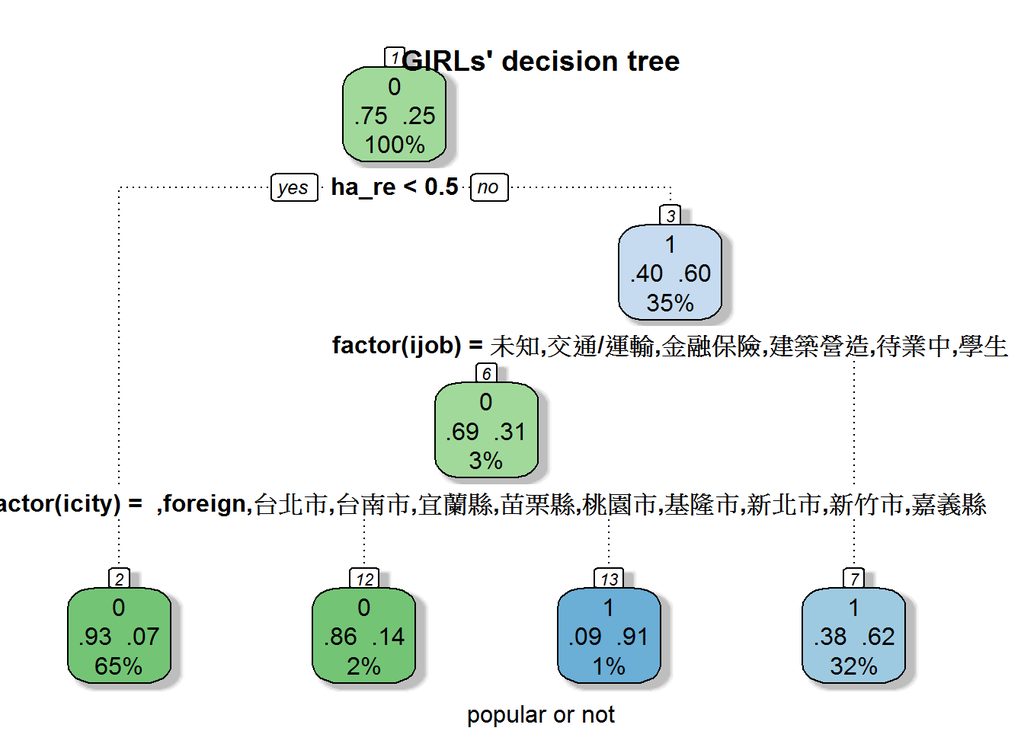

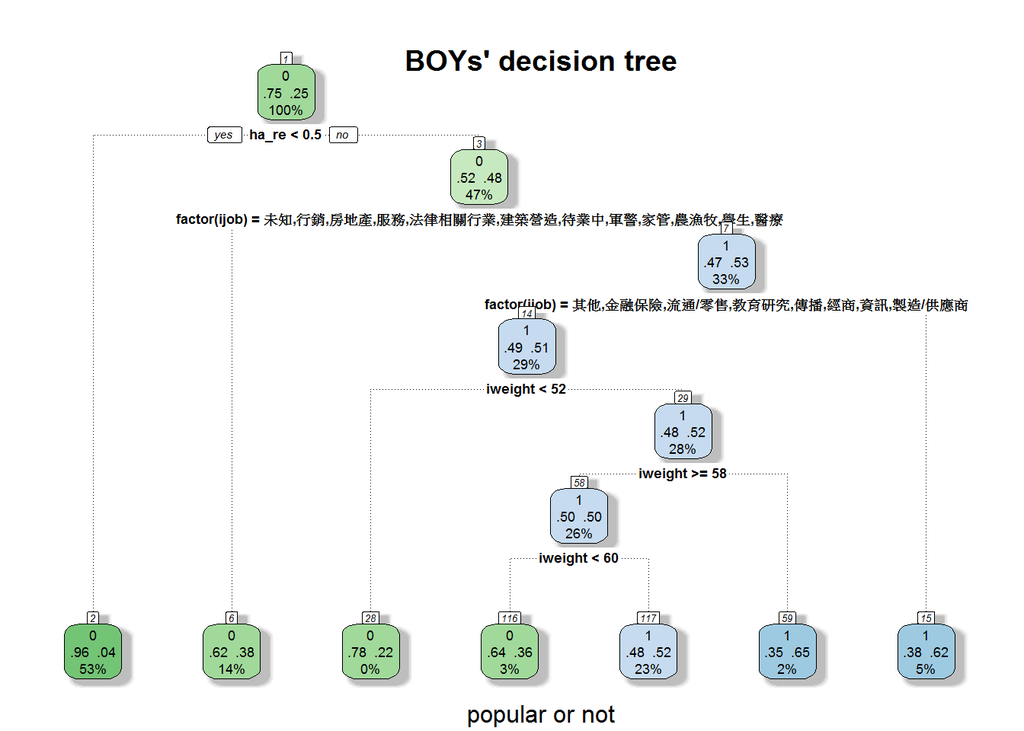

### *decision tree + kmeans clustering*

實驗方法

藉由kmeans clustering 分類出高人氣與低人氣，再以decision tree 進行特徵分析，有別於上方，我將所有變數納入模型。

實驗結果

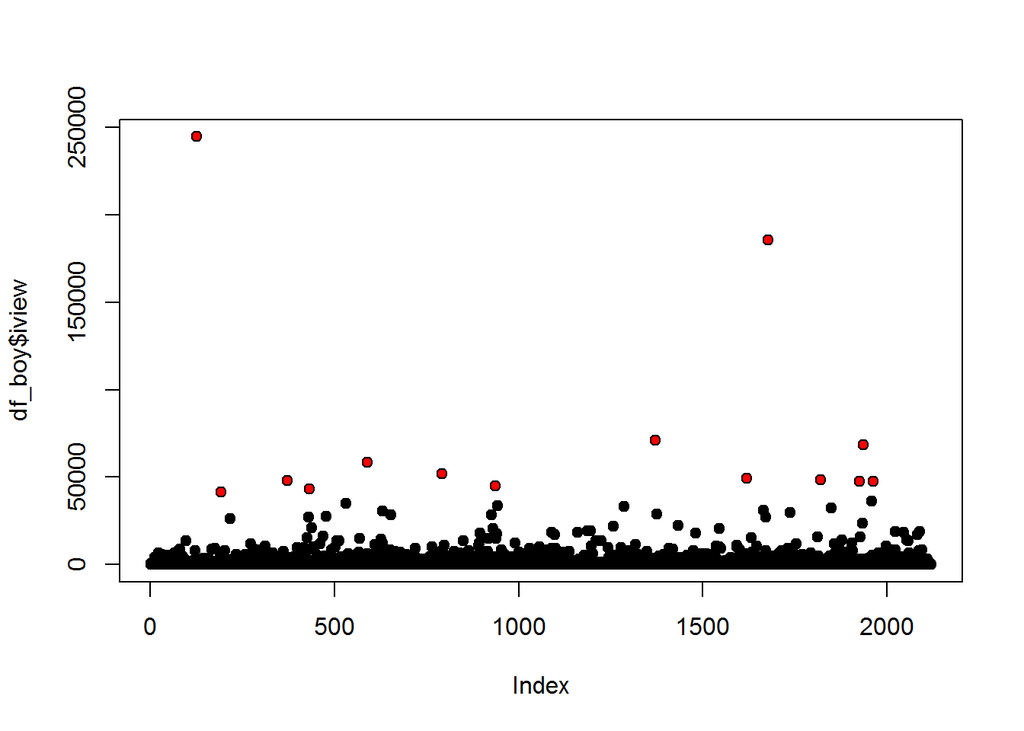

[figure not shown]

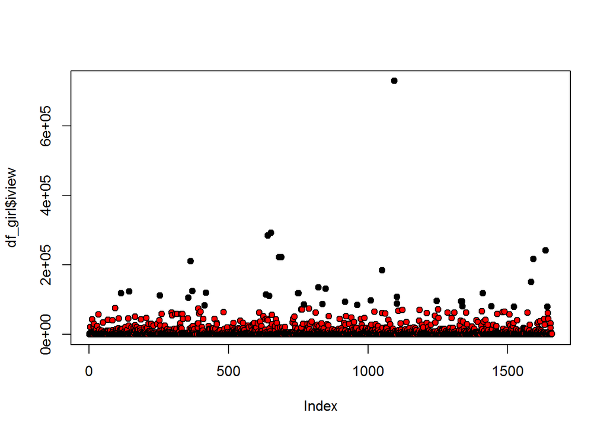

[figure not shown]

# **Part4.結論**

交友網站是現今科技發達後產生的新的交友方式，優點是它給人們一種新的交友的選擇，對於個性較內向或沒有時間認識新朋友的人無疑是項巨大的福音，但它同時也存在著缺點，隔著螢幕，我們只能得到較為片面的資訊，而且這些資訊大多是關於這人的外表或外在條件，而比較難得知對方的個性或為人。 從一開始的迴歸分析,我們所採用的significant_level為0.4以下,有別於一般所採用的0.05,0.01,其原因為大多數的因子嚴格來講並沒有對人氣造成顯著的影響力,我們猜想其中有重要遺漏變數的存在(照片),但從其中,我們仍舊可發現一些相關性,舉凡身高體重、職業、學歷等，或是一些生活習慣如抽菸喝酒的情形，從分析的內容也不難看出，在並未實際相處的這種交友模式下，通常對於交友人選的選擇會讓人有種“理想化”的感覺，身材瘦高、學歷高、不菸不酒的人通常具有較高的人氣指數，這也是交友網站的不同於實際相處的地方，也可能會間接造成和外在雖不出眾但十分優秀的人擦肩而過的情形。